# 04_screening_mtg

Gulnara Tagridzhanova

10/05/2023

**Summary:** To determine how widespread Coccomyxa viridis is in lichens, I screened metagenomic assemblies produced as a part of my recent lichen metagenomics project

## 1. Screening

- Screened 438 metagenomic assemblies from the lichen metagenomics project.
  - Accidentally included SRR13685149 Mycocalicium metagenome
- Used ITS from GT0481 as a query. The evalue threshold is based on the results on my search of the Xanthoria metagenomes, where the Trebouxia ITS was returned as a hit with the evalue of 1e-64. Deleted all empty files

```
for file in ../path/to/*_scaffolds.fasta; do sample="$(ls $file | cut -d/ -f4)"; blastn -query cviridis_its.fa -subject $file  -outfmt 6 -evalue 1e-65 -out cviridis_blast/$sample.blast; done
find cviridis_blast/ -size 0 -print -delete
```

- In total, 66 metagenomes had 84 hits
  - For example, Cladonia furcata (ERR4179389) has a low-coverage contig (1X coverage), nearly identical to the Coccomyxa from GT0481 (99% identical)
  - Alectoria fallacina (GTX0161) has a contig that blasts as Cocoomyxa antarctica (on my tree, nested within C. viridis). Its coverage is 44X, compared to 1661X of the Trebouxia ITS
- Extracted the sequences, added the name of the metagenome to the fasta headers, and concatenated into one file

```
for file in cviridis_blast/*.blast; do assembly="$(basename $file ".blast")";  bash extract_blast.sh $file ../05_MAGs/assemblies_paul/$assembly > cviridis_blast/"$assembly"_coccomyxa.fa; done

for file in cviridis_blast/*_scaffolds.fasta_coccomyxa.fa; do assembly="$(basename $file "_scaffolds.fasta_coccomyxa.fa")"; awk -v var1="$assembly"_ '/>/{{sub(">","&" var1 )}}1' $file > cviridis_blast/"$assembly"_coccomyxa_renamed.fa; done

cat  cviridis_blast/*_coccomyxa_renamed.fa > cviridis_blast/cviridis_metagenomes.fa
```

- Manually removed one hit, since it was too short and didn’t cover any portion of the ITS, only a flanking region

## 2. Phylogenetic tree

#### Constructed phylogeny

- Made a big phylogeny of Coccomyxa
- Included reference sequences from NCBI, the same as used in the tree in `../03_id_alga`
- Added the sequences I extracted from metagenomes
- Aligned and trimmed as described in `../03_id_alga`. COnstructed the tree with IQTree v2.2.2.2

```
cat analysis_and_temp_files/03_id_alga/genbank_its.fasta analysis_and_temp_files/03_id_alga/GTX0488_its.fa analysis_and_temp_files/03_id_alga/cviridis_metagenomes.fa > analysis_and_temp_files/03_id_alga/combined_its_add_metagenomes.fa
mafft --maxiterate 1000 --genafpair analysis_and_temp_files/03_id_alga/combined_its_add_metagenomes.fa > analysis_and_temp_files/03_id_alga/combined_its_aligned_add_metagenomes.fa
trimal -in analysis_and_temp_files/03_id_alga/combined_its_aligned_add_metagenomes.fa -out analysis_and_temp_files/03_id_alga/combined_its_aligned_add_metagenomes.phyl -gt 0.1 -phylip -keepheader

bash code/iqtree.sh analysis_and_temp_files/03_id_alga/combined_its_aligned_add_metagenomes.phyl 20
```

#### Annotated metagenome-derived sequences

- Retrieved the info on the metagenomes where I found Coccomyxa.
  - Used the spreadsheet from my metagenomic study to connect metagenome ID to lichen species
- Saved the list of metagenomes as `analysis_and_temp_files/03_id_alga/list_metagenomes_with_coccomyxa.txt`

```r
mtg_info<-read.delim2("../analysis_and_temp_files/04_screening_mtg/all_metagenome_reanalysis.txt")
#read the tree and use it to extract the ID of the metagenome that have Coccomyxa
library(ape)
library(tidyverse)
tree3<-read.tree("../analysis_and_temp_files/04_screening_mtg/combined_its_aligned_add_metagenomes.phyl.contree")
mtg_names<-data.frame("sequence"=tree3$tip.label) %>% filter(grepl("NODE",sequence))
mtg_names$metagenome<-sub("_.*", "", mtg_names$sequence)

#combine with the metatable on the metagenomes and save the resulting table
cocc_mtg<-data.frame("Run"=mtg_names$metagenome %>% unique) %>% left_join(mtg_info) %>% select(Run,Lichen.metagenomes)

write.table(cocc_mtg,"../analysis_and_temp_files/04_screening_mtg/list_metagenomes_with_coccomyxa.txt",sep="\t",quote = F, row.names = F, col.names=T)
```

- Manually, added to the table a column with the role of Coccomyxa (photobiont / epiphyte)
  - Used the same logic as in `03_id_alga`
  - For the lichens, where Coccomyxa is listed as the primary photobiont, I assumed that we sequence that I have are from the photobiont
  - For the rest, I put the “epiphyte” label
  - Saved as `analysis_and_temp_files/03_id_alga/list_metagenomes_with_coccomyxa2.txt`
- Combined tables for the sequences from the literature (see `03_id_alga`) and from the metagenome

```r
mtg<-read.delim2("../analysis_and_temp_files/04_screening_mtg/list_metagenomes_with_coccomyxa2.txt")
mtg2<-mtg_names %>% left_join(mtg,by=c("metagenome"="Run"))
mtg2$name<-paste0("Coccomyxa from ",mtg2$Lichen.metagenomes," metagenome")
mtg2$source<-"Lichen metagenome"

lit<-read.delim2("../analysis_and_temp_files/03_id_alga/its_id.txt",header=F)
colnames(lit)<-c("sequence","name","Coccomyxa_role","Lichen.metagenomes","Photobiont","note","link")
lit<-lit %>% mutate(source= ifelse(grepl("contig",sequence),"Strain from this paper","Literature"))
lit$metagenome<-NA

seq_info<-rbind(mtg2,lit %>% select(-note,-link))
```

#### Visualized

```r
library(ape)
library(ggtree)
tree3<-read.tree("../analysis_and_temp_files/04_screening_mtg/combined_its_aligned_add_metagenomes.phyl.contree")
tree3 <- root(tree3, outgroup = "LC660445.1", resolve.root = TRUE)
tree3 <- as.polytomy(tree3, feature='node.label', fun=function(x) as.numeric(x) < 70)
```

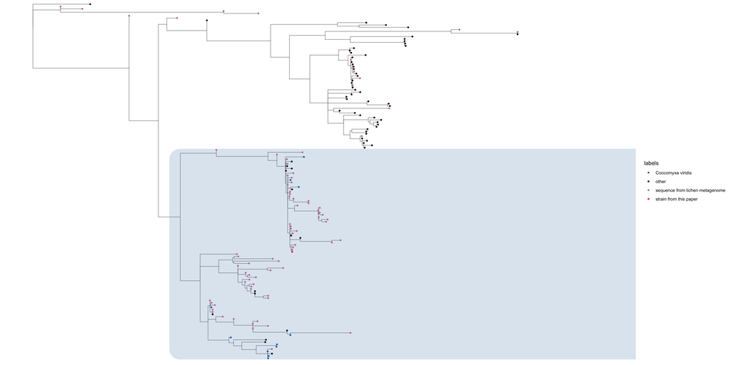

```r
##rename
seq_info<-seq_info %>% mutate(new=ifelse(Coccomyxa_role %in% c("epiphyte","photobiont"),
                          paste(sequence,name,"from",Lichen.metagenomes),
                          paste(sequence,name)))

tree3$tip.label<-seq_info[[8]][match(tree3$tip.label, seq_info[[1]])]

#make a vector for color
df<-data.frame("new"=tree3$tip.label) %>% left_join(seq_info) %>%
  mutate(labels=ifelse(grepl("contig",new),"strain from this paper",
                      ifelse(source=="Lichen metagenome","sequence from lichen metagenome",
                             ifelse(grepl("viridis",name),"Coccomyxa viridis","other"))))

p <- ggtree(tree3,ladderize = TRUE,right = T,linewidth=0.2) %<+% df +
   geom_hilight(node=165, fill="steelblue", alpha=.2,type="roundrect",extend=0.3) + geom_tippoint(aes(col=labels),size=1)+
  scale_color_manual(values=c("strain from this paper" = "red","Coccomyxa viridis"= "#0072b2", "sequence from lichen metagenome" = "#cc79a7","other"="black"))
p + xlim(0, 0.5)
```

```r
ggsave("../results/metagenomic_screening_tree.svg",device="svg",width=6,height=3)
```

- Most metagenome-derived sequences were recovered in the C. viridis clade (highlighted in blue)

#### Extracted info on lichens that have C. viridis clade

```r
library(phangorn)
leaves_id<-Descendants(tree3,165,"tips")
leaves<-tree3$tip.label[leaves_id[[1]]]

cviridis_lichens<-data.frame("new"=leaves) %>% left_join(seq_info) %>% filter(Coccomyxa_role != "non-lichen", Lichen.metagenomes != "unknown") %>% select(sequence,new,source,Lichen.metagenomes,metagenome,Coccomyxa_role, Photobiont)
colnames(cviridis_lichens)<-c("Sequence_ID","Name","Sequence_source","Lichen_species","Source_metagenome","Role","Primary_photobiont_of_the_lichen")
write.table(cviridis_lichens,"../results/lichens_with_cviridis.txt",sep="\t",quote = F, row.names = F, col.names=T)
```

#### Prepared similar list of non-C.viridis sequences

```r
leaves_id_sim<-Descendants(tree3,172,"tips")
leaves_sim<-tree3$tip.label[leaves_id_sim[[1]]]
csim_lichens<-data.frame("new"=leaves_sim) %>% left_join(seq_info) %>% filter(Coccomyxa_role != "non-lichen", Lichen.metagenomes != "unknown") %>% select(sequence,new,source,Lichen.metagenomes,metagenome,Coccomyxa_role, Photobiont)
colnames(csim_lichens)<-c("Sequence_ID","Name","Sequence_source","Lichen_species","Source_metagenome","Role","Primary_photobiont_of_the_lichen")
csim_lichens$clade<-"C. simplex/C. solorinae clade"

leaves_id_sub<-Descendants(tree3,190,"tips")
leaves_sub<-tree3$tip.label[leaves_id_sub[[1]]]
csub_lichens<-data.frame("new"=leaves_sub) %>% left_join(seq_info) %>% filter(Coccomyxa_role != "non-lichen", Lichen.metagenomes != "unknown") %>% select(sequence,new,source,Lichen.metagenomes,metagenome,Coccomyxa_role, Photobiont)
colnames(csub_lichens)<-c("Sequence_ID","Name","Sequence_source","Lichen_species","Source_metagenome","Role","Primary_photobiont_of_the_lichen")
csub_lichens$clade<-"C. subellipsoidea clade"

rest_lichens<-seq_info %>% filter(!(sequence %in% c(cviridis_lichens$Sequence_ID,
                                                  csub_lichens$Sequence_ID,
                                                  csim_lichens$Sequence_ID))) %>%
  filter(Coccomyxa_role != "non-lichen", Lichen.metagenomes != "unknown") %>% select(sequence,new,source,Lichen.metagenomes,metagenome,Coccomyxa_role, Photobiont)

colnames(rest_lichens)<-c("Sequence_ID","Name","Sequence_source","Lichen_species","Source_metagenome","Role","Primary_photobiont_of_the_lichen")
rest_lichens$clade<-"Other"


write.table(rbind(csub_lichens,csim_lichens,rest_lichens),"../results/lichens_with_other_cocc.txt",sep="\t",quote = F, row.names = F, col.names=T)
```

#### Mapped the metagenomes in which Coccomyxa viridis was detected

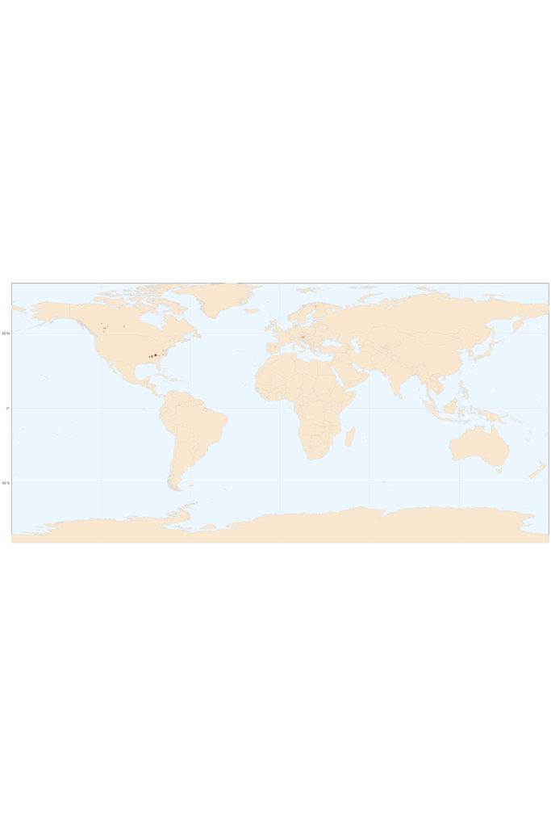

```r
library(ggmap)
library(sf)
library("rnaturalearth")
library("rnaturalearthdata")

locations<-read.delim("../analysis_and_temp_files/04_screening_mtg/locations_metagenomes.txt")
locations_selected<-locations %>% right_join(cviridis_lichens,by=c("run_accession"="Source_metagenome")) %>% select(run_accession,lat,long) %>% distinct()

world <- ne_countries(scale = "medium", returnclass = "sf")
ggplot(data = world) +
  geom_sf(fill= "antiquewhite",color="lightgrey",size=0.2)+
  coord_sf(expand = FALSE)+
  geom_point(data = locations_selected, aes(x = as.numeric(long), y = as.numeric(lat)), color = "brown", size = 1,alpha=.3)+
  theme_minimal()+
 theme(axis.title.x=element_blank(),
       axis.title.y=element_blank(),
       axis.text.x = element_blank(),
       panel.background = element_rect(fill = "aliceblue"))
```

```r
ggsave("../results/map.pdf",width=4,height=3)
```

#### Plotted the percent of metagenomes in which C. viridis was detected

```r
###count metagenomes per order (or per class, for non-lecanoromycetes)
mtg_per_order<-mtg_info %>% mutate(order2 = ifelse(class=="Lecanoromycetes",order,class)) %>% group_by(order2) %>% summarise(order_screened=n())

###count C.viridis-containing metagenomes
cvir_mtg_per_order<-cocc_mtg %>% filter(Run %in% cviridis_lichens$Source_metagenome) %>% left_join(mtg_info) %>%
  mutate(order2 = ifelse(class=="Lecanoromycetes",order,class)) %>%
  group_by(order2) %>% summarise(order_cvir=n())

###combine and visualize
df<-mtg_per_order %>% left_join(cvir_mtg_per_order) %>% mutate_if(is.numeric,coalesce,0) %>%
  mutate(cvir_pres=order_cvir/order_screened,cvir_abs=1-order_cvir/order_screened)
df
```

```
## # A tibble: 23 × 5
##    order2           order_screened order_cvir cvir_pres cvir_abs
##    <chr>                     <dbl>      <dbl>     <dbl>    <dbl>
##  1 Acarosporales                 4          0    0         1
##  2 Arthoniomycetes              20          3    0.15      0.85
##  3 Baeomycetales                10          5    0.5       0.5
##  4 Caliciales                   47          1    0.0213    0.979
##  5 Coniocybomycetes              2          0    0         1
##  6 Dothideomycetes               8          1    0.125     0.875
##  7 Eurotiomycetes               13          1    0.0769    0.923
##  8 Gyalectales                  27          5    0.185     0.815
##  9 Lecanorales                 200         23    0.115     0.885
## 10 Lecideales                   11          1    0.0909    0.909
## # ℹ 13 more rows
```